# RayBiotech DED-Cytokine Array Analysis

e1-359

# Tidying the Data

**Sample Guide:**

| sample_codes | sample_names |
| --- | --- |
| SA1 | healthy-ser-cntrl |
| SA2 | CMM2-1b |
| SA3 | CMM2-1c |
| SA4 | 83b |
| SA5 | 76-OD |
| SA6 | 81-OS |
| SA7 | 83a |
| SA8 | 73a-OD |

Some notes on the samples and the data:

- The serum samples were collected by differnt individuals and may have been processed differently. For example, different protocols for isolating plasma or serum.
  - SA1 provided by the Knight BioLibrary
  - SA2 processed by Tammie Haley
  - SA3 processed by Tammie Haley
  - SA4 (83b) was collected by Paul Yang

## Convert to Long format

Load in output from RayBiotech Excel analysis tool

```r
#cytokine concentrations calculated from linear regression standard curves
cytokines_linReg <- read_excel(path = here("data/Stdev-sheet_unprotected.xlsx"), sheet = "Stdev_linear-reg")

#cytokine concentrations calculated from log-log regression standard curves
cytokines_logReg <- read_excel(path = here("data/Stdev-sheet_unprotected.xlsx"), sheet = "Stdev_log-reg")
```

Make data *long* rather than *wide* with `pivot_longer()`

```r
cytokines_linReg <-  pivot_longer(cytokines_linReg, cols = 2:ncol(cytokines_linReg), names_to = "sample", values_to = "concentration")
cytokines_logReg <- pivot_longer(cytokines_logReg, cols = 2:ncol(cytokines_logReg), names_to = "sample", values_to = "concentration")


cytokine_data_list <- list("cytokines_linReg" = cytokines_linReg)
                           #, "cytokines_logReg" = cytokines_logReg)
```

## Separate the concentration and SD into separate variables

Strategy = Use Regex to:

- identify numbers *before* a “+” –> cytokine concentration value
- identify numbers *after* a “-” –> standard deviation value

```r
#regex patterns to find numbers before and after the plus and minus symbols in the dataframe
before_plus_pattern <- "[:digit:]+"
after_minus_pattern <- "[:digit:]+$"

#pattern to recognize "+/-" and split string on either side
split_pattern <- "\\+/-"


#function for make new cols for SD and concentration using str_extract
tidy_split <- function(dataframe, pattern1, pattern2) {
  dataframe <- dataframe %>%
    mutate(SD = str_extract(string = dataframe$concentration, pattern = pattern1),
            concentration = str_extract(string = dataframe$concentration, pattern = pattern2)) %>%
    mutate(SD = as.integer(SD),
           concentration = as.integer(concentration)) %>%
    arrange(sample)
}

cytokine_data_list <- lapply(cytokine_data_list, tidy_split, pattern1 = after_minus_pattern, pattern2 = before_plus_pattern)
```

# Parametric Tests

Determine what kind of stats will be used for testing this data

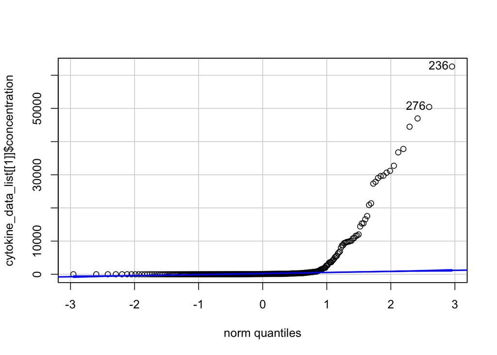

```
## [1] 236 276
```

```r
car::qqPlot(cytokine_data_list[[1]]$concentration)
```

Data do not appear parametric by visualization

```r
shapiro.test(cytokine_data_list[[1]]$concentration)
```

```
##
##  Shapiro-Wilk normality test
##
## data:  cytokine_data_list[[1]]$concentration
## W = 0.38864, p-value < 2.2e-16
```

p << 0.05 : Data are not normally distributed

# Displaying the Data

## Heat Map

Given the size and complexity of the data, heatmap may be a good start to understand broad patterns. After exploring large-scale patterns, I can create other plots with more nuanced comparisons

Plotting function

```r
#remove SDs, convert to matrix, heatmap()
heatmap_plot3 <- function(dataframe,legend_name, plotvar = "concentration", multiplier = 1, ...) {

  fill_value <- NULL
  if(multiplier == 1){
    fill_value <- unlist(dataframe[plotvar])
    legend_name_addon <- ""
  }
  else if (multiplier == "log2"){
    fill_value <- unlist(log2(dataframe[plotvar]))
    legend_name_addon <- "(Log2)"
  }

  dataframe %>%
    select(!"SD") %>%
      ggplot(mapping = aes(x = cytokine, y = sample, fill = fill_value ))+
      geom_tile() +
      xlab("Cytokine") +
      ylab("Sample") +
      scale_fill_continuous(type = "viridis", name = paste(legend_name, " ", legend_name_addon))+
      theme_classic()+
      theme(axis.text.x = element_text(angle = 90, vjust = 0.5))
}
```

### Serum and Aqueous Humor Together

These data were normalized to positive controls on the array, but not to any of the positive control *samples* we included (such as healthy control serum or aqueous humor)

#### Raw Concentration Values

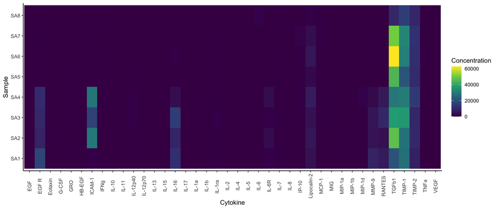

```r
lapply(cytokine_data_list, heatmap_plot3 , legend_name = "Concentration", multiplier = "1")
```

#### Log2 Transformation

The data span a large range of concentrations so I’m plotting it on a log scale for legibility

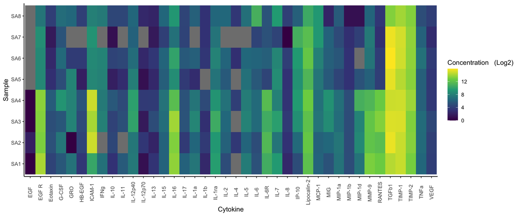

```r
lapply(cytokine_data_list, heatmap_plot3 , legend_name = "Concentration", multiplier = "log2")
```

### Serum Only Data

Since we have a healthy serum positive control (*SA1*), I can normalize the MAR serum to this sample:

- Fold Change = y/x
- Log2 FC = log2(y) - log2(x)

```r
#keep only the serum samples in each list (SA1 - SA4)
serum_samples <- c("SA1", "SA2", "SA3","SA4")
cytokine_serum_list <- lapply(cytokine_data_list, filter, sample == "SA2" | sample == "SA1" | sample == "SA3" | sample == "SA4")

#function for normalizing to SA1; "Fold Change" (y/x)
SA1_normalize <- function(df){
  df <- df %>%
    mutate(FC = (concentration/concentration[df$sample == "SA1"]),
           FC = round(FC, digits = 3)) %>%
    mutate(log2_FC = log2(concentration) - log2(concentration[df$sample == "SA1"]),
           log2_FC = round(log2_FC, digits = 3))
}


#list with dataframes that only have serum samples and concentration is normalized to SA1
cytokine_serum_list <- lapply(cytokine_serum_list, SA1_normalize)
```

#### Fold Change in Concentration

Fold Change = y/x

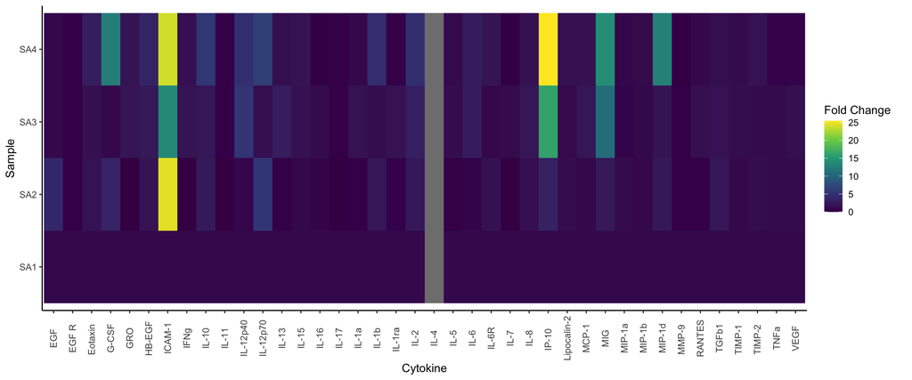

```r
lapply(cytokine_serum_list, heatmap_plot3, plotvar = "FC", legend_name = "Fold Change", multiplier = 1)
```

#### Log2 Fold Change in Concentration

Log2 FC = log2(y) - log2(x)

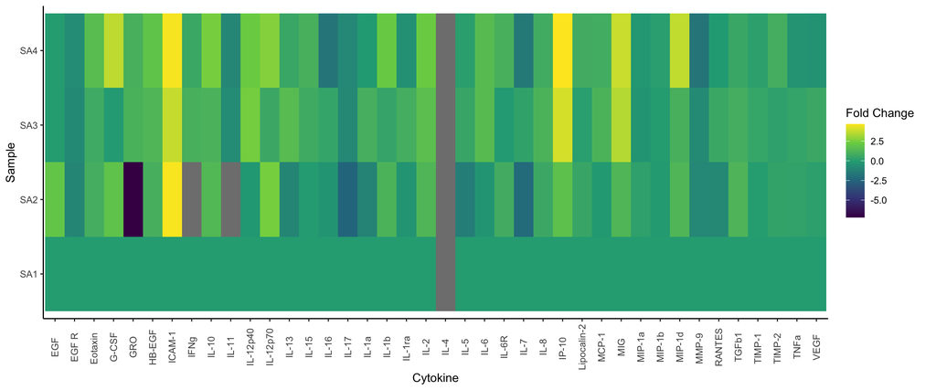

```r
lapply(cytokine_serum_list, heatmap_plot3, plotvar = "log2_FC", legend_name = "Fold Change", multiplier = 1)
```

**Observations**

- IL-4 is not present in SA1 (concentration == 0), so there are several *infinite* or *NA* values in the normalized data that come from dividing by 0

## Volcano Plot

**Statistical** Test: `Wilcox Test`

- Variables: 1
- Quantitative data
- Non-parametric

Determined using the [flow chart for statistical tests](https://statsandr.com/blog/files/overview-statistical-tests-statsandr.pdf)

Get the concentration values of just SA1 as a vector

Make comparisons using `group_by` with the rest of the samples